# CuVec: Python - C/C++ - CUDA | Casper da Costa-Luis

## CuVec: Unifying Python/C++/CUDA memory

[figure not shown]

**Python buffered array ↔ C++11 `std::vector` ↔ CUDA managed memory**

3 May 2023 [Casper da Costa-Luis](https://cdcl.ml)

# Motivation

- One problem, one language
- Two problems, two languages
  - interfaces

## Prior Art

- Lots of boilerplate (CPython API)
- Pre-TensorFlow/PyTorch (no high-level frameworks)
- Pre-SSDs (HDD I/O)

## New Hope: Language Features

- C++11 (ISO/IEC#14882:2011 alias templates, container/`std::vector` allocators)
- CUDA 6 ([unified memory](https://developer.download.nvidia.com/compute/cuda/6_0/rel/docs/CUDA_Toolkit_Release_Notes.pdf))
- Python 3 ([PEP#3118](https://peps.python.org/pep-3118) array [buffer protocol](https://docs.python.org/3/c-api/buffer.html)), 3.6 ([`float16`](https://doi.org/10.1109/IEEESTD.2019.8766229))
- Python [`__cuda_array_interface__`](https://numba.readthedocs.io/en/latest/cuda/cuda_array_interface.html) (Numba, CuPy, PyTorch, PyArrow, ArrayViews, JAX, PyCUDA, DALI, RAPIDS, ...)

## More Hope: Build Tooling

- Python 3.6 build-system dependencies ([PEP#517](https://www.python.org/dev/peps/pep-0517), [PEP#518](https://www.python.org/dev/peps/pep-0518))
- [`scikit-build`](https://scikit-build.readthedocs.io) (CMake-driven build-system generator for CPython extensions)
- PIP availability: [CMake generator](https://cmake-python-distributions.readthedocs.io) & [Ninja build-system](https://github.com/scikit-build/ninja-python-distributions)
- (optional) SWIG
- TL;DR
  - dev: `pyproject.toml` + `setup.py` + `CMakeLists.txt`
  - user: C++/CUDA compiler (any OS, no IDE) + `python3.6 -m pip install cuvec`

# Solution: Building CuVec

- 1 decade of frustration careful thought
- 2 days of prototyping + 5 days of testing

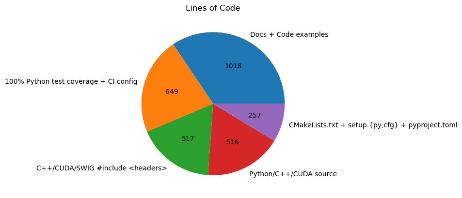

```python
git_fame_plot("./cuvec", bytype=True)
```

# Summary: Winning

- Less boilerplate code (fewer bugs, easier debugging, and faster prototyping)
- Fewer memory copies (faster execution)
- Lower memory usage (do more with less hardware)

## What Next

- Integration tutorials (Numba, CuPy, PyTorch, PyArrow, ArrayViews, JAX, PyCUDA, DALI, RAPIDS, ...)
- ... any feature requests?

| [Casper da Costa-Luis](https://cdcl.ml) |  |  |
| --- | --- | --- |